# Portfolio 6: Thesis Part 6 (Updated Figures)

This is part 6 of the analyses for my master’s thesis project, which was titled “Effects of a Short-Term Volitional Intervention Promoting Moral and Non-Moral Personality Change.” Here is the abstract of my thesis for some context:

> People can intentionally change specific personality traits. However, it is unclear whether such interventions are effective at changing moral character traits. The present study (total N = 179), which utilized two active intervention groups for mutual comparisons, examined whether a 5-week goal-setting intervention could lead to trait change for a moral trait, compassion (n = 87), or the Big 5 trait of conscientiousness (n = 92). Participants self-selected into one condition after getting feedback on where they stood on these traits in relation to the population norm and completing a brief reflection task. They set implementation intentions and reflected on their progress every 3 days for the duration of the intervention. State assessments were collected every 3 days in addition to self- and observer-report trait assessments at pre- and post-test, with follow-up self-report assessments 2 weeks post-program. Results from analyses of self-report trait and state assessments indicated that participants in both intervention groups were able to successfully change their personalities in the short term, providing preliminary evidence that implementation intention-based volitional personality change interventions can be useful tools for both moral and non-moral trait change.

After I gave my SWell presentation on 2/15/23 (which was preparation for an SPSP Data Blitz I was to give the following week), I wanted to implement some of the suggestions people made to make my figure(s) easier to read and to better convey the results of my study. This portfolio documents that process!

### Loading Packages and Data

```r
library(jtools)
library(foreign)
library(tidyverse)
VPCDescriptives = read.spss("VPCdescriptives_2.21.23.sav",
                      to.data.frame = TRUE,
                      reencode = TRUE,
                      use.value.labels = FALSE)
```

```
## re-encoding from UTF-8
```

```r
VPCDescriptives$intervention <- as.factor(VPCDescriptives$intervention)

VPCDescriptives$intervention_label <- as.factor(VPCDescriptives$intervention_label)

VPCDescriptives$datalevel <- as.factor(VPCDescriptives$datalevel)


VPCDescriptives_trait <- filter(VPCDescriptives, datalevel == 1)
CompDesc_trait <-filter(VPCDescriptives_trait, intervention == 0)
ConsDesc_trait <-filter(VPCDescriptives_trait, intervention == 1)

VPCDescriptives_state <- filter(VPCDescriptives, datalevel == 2)
CompDesc_state <-filter(VPCDescriptives_state, intervention == 0)
ConsDesc_state <-filter(VPCDescriptives_state, intervention == 1)
```

### Plot #1

With this plot, I finally figured out how to adjust the colors in the right way!!

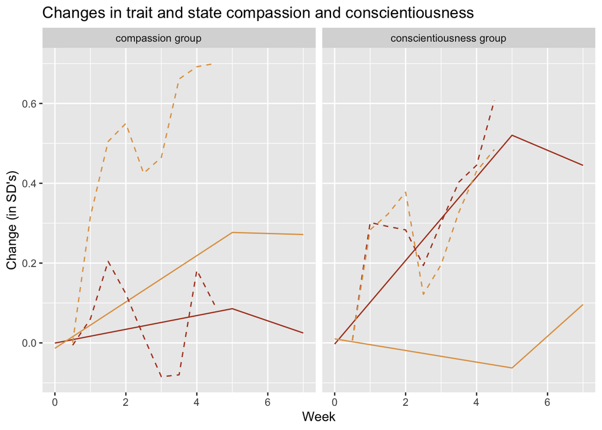

```r
TraitStateChanges <- ggplot() +
  geom_line(data = VPCDescriptives_trait, aes(x = week, y = cons_changeinSD, color = intervention), color = '#B04326') +
  geom_line(data = VPCDescriptives_trait, aes(x = week, y = comp_changeinSD, color = intervention), color ='#E0A151') +
  geom_line(data = VPCDescriptives_state, aes(x = week, y = cons_changeinSD, color = intervention, linetype = datalevel), linetype = "dashed", color = '#B04326') +
  geom_line(data = VPCDescriptives_state, aes(x = week, y = comp_changeinSD, color = intervention, linetype = datalevel),linetype = "dashed", color = '#E0A151') +
  labs(color = "Intervention Group", linetype = "Data Level",title = "Changes in trait and state compassion and conscientiousness",
       x = "Week", y = "Change (in SD's)") +
     facet_wrap(~ intervention_label)

TraitStateChanges
```

I still couldn’t figure out how to add a legend in the way I wanted to, though.

### Plot #2

My main task for this next plot was to try to make everything easier to read (especially from a distance). I also needed to figure out how to add two separate legends: one for line type (which distinguished state vs. trait data) and one for color (which distinguished compassion vs. conscientiousness). I also started experimenting with custom figure sizes (and custom font sizes, etc.) to get the overall scale right.

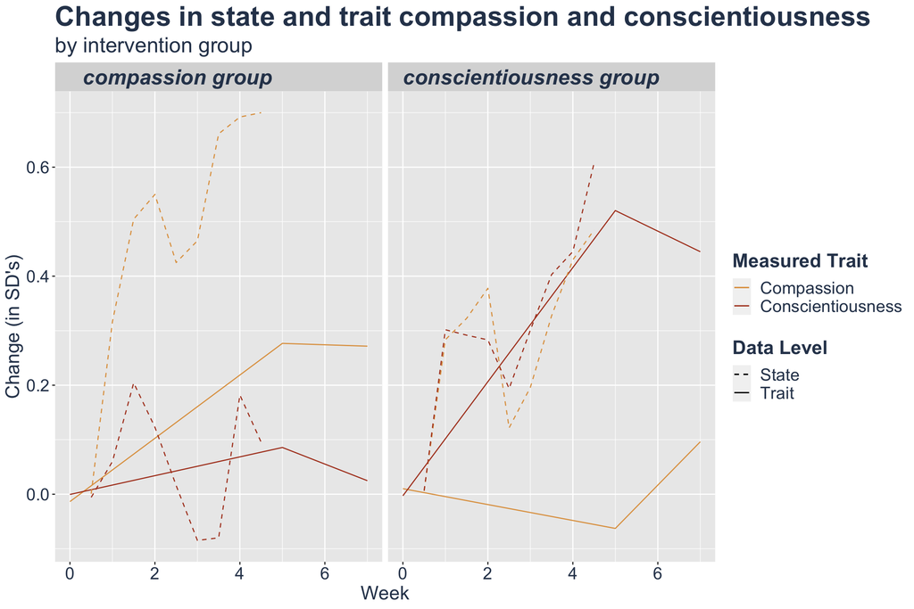

```r
PlotPart2 <- ggplot()+
    geom_line(data = VPCDescriptives_trait, aes(x= week, y = comp_changeinSD,color = "Compassion", linetype = "Trait"))+
    geom_line(data = VPCDescriptives_trait, aes(x= week, y = cons_changeinSD,color="Conscientiousness", linetype = "Trait"))+
    geom_line(data = VPCDescriptives_state, aes(x= week, y = comp_changeinSD,color = "Compassion", linetype = "State"))+
    geom_line(data = VPCDescriptives_state, aes(x= week, y = cons_changeinSD,color="Conscientiousness", linetype = "State"))+
    labs(title = "Changes in state and trait compassion and conscientiousness", subtitle = "by intervention group", colour="Measured Trait",linetype = "Data Level", x="Week",y="Change (in SD's)")+
  facet_wrap(~ intervention_label) +
    theme(plot.title = element_text(color = "#2E415A", size = 26, face = "bold"),
          plot.subtitle = element_text(color = "#2E415A", size = 20),
          strip.text.x = element_text(color = "#2E415A", size = 20, face = "bold.italic"),
      legend.title = element_text(color = "#2E415A", size = 18, face = "bold"),
      legend.text = element_text(color = "#2E415A", size = 16),
      axis.title = element_text(color = "#2E415A", size = 18),
      axis.text = element_text(color = "#2E415A", size = 16))+
    scale_color_manual(values = c("#E0A151","#B04326")) +
    scale_linetype_manual(values = c("dashed", "solid"))


PlotPart2
```

This was pretty close to what I wanted!

### Plot #3: Final Figure for Presentation

Next, I needed to work on adjusting the line thickness to keep working on making things easier to read. I also figured out that it made more sense to add my title/subtitle in Powerpoint itself so I could have the margins in between the text and the graph that I wanted. (I couldn’t figure out how to easily adjust that with ggplot code, and this approach just seemed more straightforward). So for this next plot, I got rid of the title and subtitle.

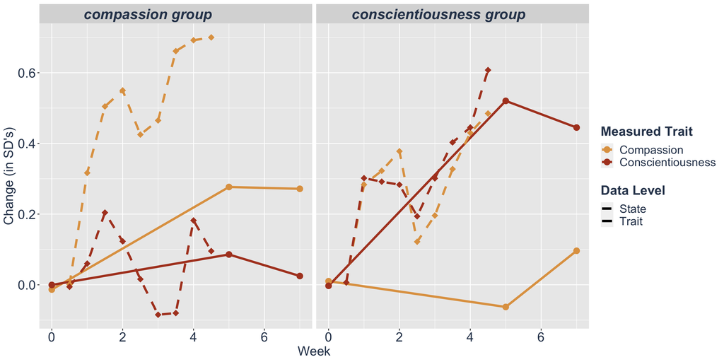

```r
PlotPart3 <- ggplot()+
    geom_line(data = VPCDescriptives_trait, aes(x= week, y = comp_changeinSD,color = "Compassion", linetype = "Trait"), linewidth = 1.5)+
    geom_line(data = VPCDescriptives_trait, aes(x= week, y = cons_changeinSD,color="Conscientiousness", linetype = "Trait"), linewidth = 1.5)+
    geom_line(data = VPCDescriptives_state, aes(x= week, y = comp_changeinSD,color = "Compassion", linetype = "State"), linewidth = 1.5)+
    geom_line(data = VPCDescriptives_state, aes(x= week, y = cons_changeinSD,color="Conscientiousness", linetype = "State"), linewidth = 1.5)+
  geom_point(data = VPCDescriptives_trait, aes(x= week, y = comp_changeinSD,color = "Compassion"), size = 4, shape = 16)+
    geom_point(data = VPCDescriptives_trait, aes(x= week, y = cons_changeinSD,color="Conscientiousness"), size = 4, shape = 16)+
    geom_point(data = VPCDescriptives_state, aes(x= week, y = comp_changeinSD,color = "Compassion"), size = 4, shape = 18)+
    geom_point(data = VPCDescriptives_state, aes(x= week, y = cons_changeinSD,color="Conscientiousness"), size = 4, shape = 18)+
    labs(colour="Measured Trait",linetype = "Data Level", x="Week",y="Change (in SD's)")+
  facet_wrap(~ intervention_label) +
    theme(plot.title = element_text(color = "#2E415A", size = 26, face = "bold"),
          plot.subtitle = element_text(color = "#2E415A", size = 20),
          strip.text.x = element_text(color = "#2E415A", size = 20, face = "bold.italic"),
      legend.title = element_text(color = "#2E415A", size = 18, face = "bold"),
      legend.text = element_text(color = "#2E415A", size = 16),
      axis.title = element_text(color = "#2E415A", size = 18),
      axis.text = element_text(color = "#2E415A", size = 18))+
    scale_color_manual(values = c("#E0A151","#B04326")) +
    scale_linetype_manual(values = c("dashed", "solid"))


PlotPart3
```

I think this looks a lot better than my original figure and I’m happy with the result!

### Plot #4: Final Figure for Paper (APA Style)

For my thesis (the paper itself), I needed to create an APA-style version of the above figure that would blend in nicely with the formatting of my text. Towards this end, I used an [apa-style ggplot theme from the jtools package (created by Jacob Long)](https://rdrr.io/cran/jtools/man/theme_apa.html).

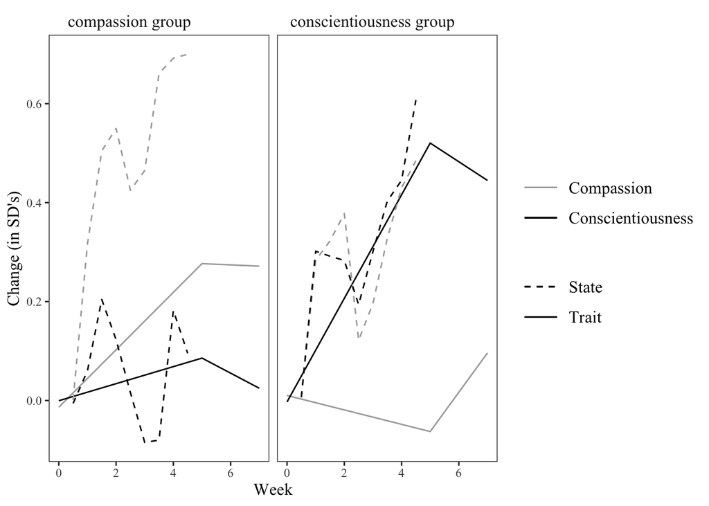

```r
APAPlot <- ggplot()+
    geom_line(data = VPCDescriptives_trait, aes(x= week, y = comp_changeinSD,color = "Compassion", linetype = "Trait"))+
    geom_line(data = VPCDescriptives_trait, aes(x= week, y = cons_changeinSD,color="Conscientiousness", linetype = "Trait"))+
    geom_line(data = VPCDescriptives_state, aes(x= week, y = comp_changeinSD,color = "Compassion", linetype = "State"))+
    geom_line(data = VPCDescriptives_state, aes(x= week, y = cons_changeinSD,color="Conscientiousness", linetype = "State"))+
    labs(colour="Measured Trait",linetype = "Data Level", x="Week",y="Change (in SD's)")+
  facet_wrap(~ intervention_label) +
 theme_apa(
  legend.pos = "right",
  legend.use.title = FALSE,
  legend.font.size = 12,
  x.font.size = 12,
  y.font.size = 12,
  facet.title.size = 12,
  remove.y.gridlines = TRUE,
  remove.x.gridlines = TRUE)+
    scale_color_manual(values = c("darkgrey","black")) +
    scale_linetype_manual(values = c("dashed", "solid"))

APAPlot +
  theme(text = element_text(family = "Times New Roman"))
```